# *RLBase*

Documentation and FAQs

2021-10-03

# Introduction

R-loops are three-stranded nucleic acid structures formed from the hybridization of RNA and DNA. With the advent of DNA-RNA immunoprecipitation sequencing (DRIP-Seq) in 2012, it become possible to map R-loop locations throughout the genome (Ginno et al. 2012). To date, over 40 such studies have been performed, yielding hundreds of R-loop maps across a variety of species. **However, inconsistent data quality has thus far thwarted every attempt to use meta-analysis to draw deeper insights about R-loop biology from this trove of data.**

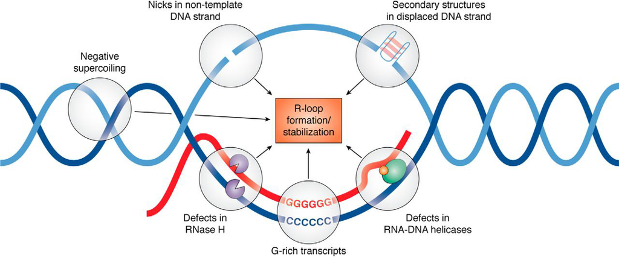

Depiction of an R-loop and the factors which may promote them (Hegazy et al., 2020; PMID: [31843970](https://pubmed.ncbi.nlm.nih.gov/31843970/)).

**To overcome this limitation, we developed RLSuite, a suite of tools for R-loop analysis with built-in quality control**. RLSuite includes RLPipes (a CLI pipeline for upstream R-loop data processing), RLSeq (R package for downstream R-loop data analysis), and RLBase (a web server and database to explore the results).

[figure not shown]

*RLBase* is the first web server and database that provides un-restricted access to **standardized and quality-controlled R-loop mapping data from hundreds of publicly-available samples**. Moreover, process of curating these data has allowed us to confidently identify **R-loop regions (RL Regions), sites of consensus R-loop formation**. The RLBase web server is designed to enable access to all datasets along with the tools necessary to analyze them and evaluate user-supplied data.

Our goal in this document is to **(1) showcase the intended usage of RLBase and (2) address FAQs which may arise when using RLBase**.

**Terminology explained**

In this subsection, we describe the terminology used in *RLBase* to help aid in its usage.

### Modes

RLBase contains R-loop mapping data from high-throughput sequencing experiments. There are, to date, over 20 different methods of R-loop mapping included in *RLBase*. To help summarize them, we have provided the following visualization:

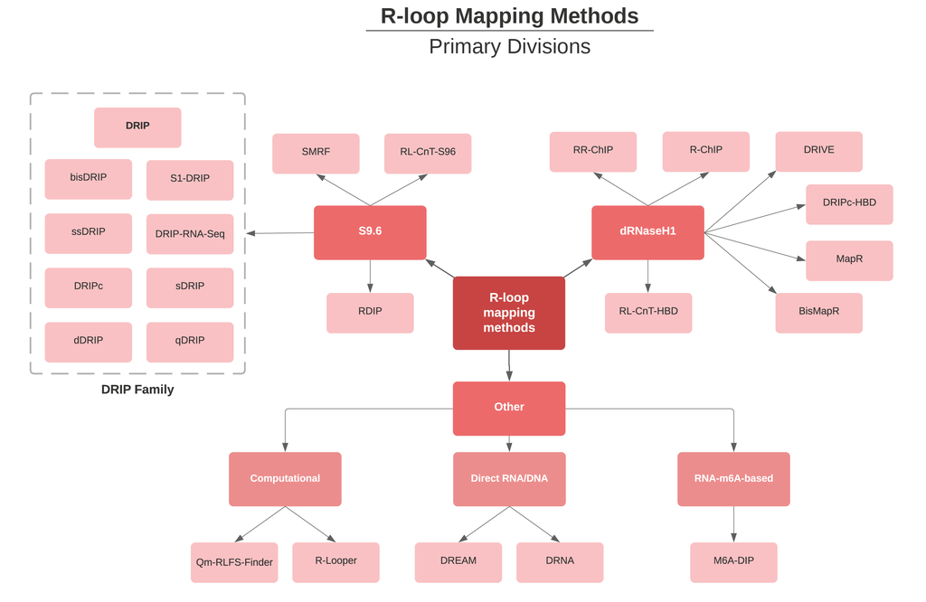

Diagram showing the different R-loop mapping methods which exist. All of these are found in RLBase (except computational methods, SMRF-Seq, and bisDRIP-Seq).

# Usage

The core features we intend *RLBase* to be used for are:

- Exploration of R-loop mapping samples (view)
  - Exploration of mapping samples from different modalities
  - Analysis of sample quality
  - Analysis of genomic feature enrichment
- R-loop Region (RL Region) analysis (link)
  - Exploration of R-loop regions
  - Analysis of R-loop region correlation with gene expression
- User-supplied samples (view)
  - Analysis of user-supplied data

## Analysis of RLBase samples

To view samples in the RLBase database, navigate to the “Samples” tab.

**Sample-page components explained**

In this subsection, we detail the elements of the sample page to help elucidate its usage.

[figure not shown]

## Exploration of R-loop regions

# References

Ginno, Paul A., Paul L. Lott, Holly C. Christensen, Ian Korf, and Frédéric Chédin. 2012. “R-Loop Formation Is a Distinctive Characteristic of Unmethylated Human CpG Island Promoters.” *Molecular Cell* 45 (6): 814–25. https://doi.org/10.1016/j.molcel.2012.01.017.